# Kapittel 4

## Kapittel 4: Økonomisk teori 2: Forsikring

4.1 Introduksjon

4.2 Etterspørselen etter forsikring

4.3 Tilbudssiden

4.4 Forsikringsmarkedet som helhet: Privat og sosialforsikring

## 4.1 Introduksjon

## Begrepsavklaring

- Usikkerhet (subjektiv risiko)
  - Psykologisk reaksjon på manglende kunnskap om framtidige utfall
  - Kjenner ikke (nøyaktig) sannsynlighetene for ulike utfall
  - «Optimering under usikkerhet»
- Risiko
  - Mulighet for tap/skade («sjokk»)
  - Positive sannsynlighet for flere utfall, hvor minst ett av utfallene er uønsket
  - Objektivt mål basert på observerte skadeandeler
  - Kjenner sannsynlighetene for ulike utfall
  - Forsikring = risikodeling (risk sharing)
  - Individuell risiko (idiosyncratic risk)
  - Systematisk risiko (aggregate risk, covariate risk)
- Fare (peril)
  - Årsak til tap (brann, kollisjon, tyveri, osv.)
- Hasard
  - En tilstand som kan øke sannsynligheten for tap eller skade
    - “Hasardiøs kjøring”

## Forsikring (definisjon)

- et redskap for å beskytte enkeltpersoner mot risiko
- en aktuarisk mekanisme
  - Et forsikringsselskap må regne ut hvor mye en kunde skal betale for en forsikring på forhånd

## Hva er aktuarisk nøytral premie?

- Aktuarisk nøytral forsikringspremie (aktuariell premie)
- Innbetalingen er lik forventet utbetaling for forsikringsselskapet (for enhver risikogruppe)
- Forsikringspremien er lik forventet tap ved skade for forsikringstaker

*Premie<sub>i</sub> = (1+α) p<sub>i</sub>L*,

der

*p<sub>i</sub>* = sannsynligheten for at begivenheten vil inntreffe

*L* = størrelsen på tapet

*α* = transaksjonskostnader o.l.

- Forsikringsselskap vet at 1 promille av villaene vil brenne ned til grunne hvert år. Hver villa er i gjennomsnitt verdt kr 2 mill.
- Forsikringspremien (*r*) på hver bolig blir da kr 2000 per år

## To spørsmål

- Hvorfor forsikrer folk seg frivillig (spørsmålet på etterspørselssiden)?
- Under hvilke forhold vil det private markedet tilby forsikring effektivt (spørsmålet om tilbudssiden)?

## 4.2 Etterspørsel etter forsikring

## 4.2.1 Individuell etterspørsel

- Hvordan kan en rasjonell person velge å forsikre seg når den forventede utbetalingen er mindre enn hans premieinnbetalinger?
- Hvis en person er risikoavers, forårsaker usikkerhet negativ nytte
  - Derfor er sikkerhet en vare som gir positiv marginal nytte, som han er forberedt på å betale en positiv pris for

## 4.2.2 Forsikring som mekanisme for risikodeling

- De to intellektuelle begrunnelsene for forsikring:
  - **Loven om store tall: enkeltpersoner kan møte usikkerhet, men grupper kan møte omtrentlig sikkerhet**
    - Nesten ingenting er så usikkert som levealderen til et nyfødt barn,
    - og nesten ingenting er så sikkert som gjennomsnittlig levealder til 1000 nyfødte barn
  - **Gevinster fra handel oppstår fra enkeltpersoner som går med på å samle (“pool”) risiko**
    - Overføring av risiko fra individ til gruppe
      - Variansen (og risikoen) på individnivå forsvinner
      - Individene foretrekker sikkerhet framfor usikkerhet

## 4.3 Tilbudssiden

## Tilbud av forsikring, forutsetninger

$$\pi_i = (1+α) p_iL$$

1. De individuelle sannsynlighetene for ulykke/skade ($p_i$) er uavhengig av hverandre (ingen systematisk risiko)
2. Må ha usikkerhet, dvs. manglende kunnskap om framtidig utfall $p_i \le 1$
- om $p_i = 1$, da blir $\pi = (1+α)L > L$
3. Risiko, ikke usikkerhet (sannsynlighet må være kjent eller mulig å estimere (forsikringsselskapet må vite gjennomsnittlig $p_i$)
4. Ingen asymmetrisk informasjon
- ingen ugunstig utvalg
  - forsikringsselskapet kjenner ikke individuelle $p_i$ og forsikring er frivillig
  - Økende andel dårlig risiko
- ingen moralsk hasard - Individene kan påvirke $p_i$ (eller $L$)
  - Påvirke $p_i$ (ex ante moralsk hasard)
    - forsikringstakeren kan påvirke sannsynlighet for tap eller størrelse på potensielt tap, gjennom strategisk adferdsendring
    - for eksempel ingen forebygging
  - Påvirke $L$ (ex post moralsk hasard)
    - knyttes til endret adferd fra forsikringstakeren etter at risikoen er inntruffet, men før kompensasjonskravet sendes til selskapet
    - Forsikringstakeren har derfor mulighet til å påvirke skadebeløpet, og derfor kompensasjonsbeløpet

## Markedssvikt

1. Felles sjokk i stedet for individuell risiko, det vil si gjensidig avhengige sannsynligheter
2. Sikkerhet i stedet for risiko, det vil si sannsynlighet nærmer seg en
3. Usikkerhet, det vil si at risikoen ikke er kjent eller mulig å estimere
4. Asymmetrisk informasjon:
- ugunstig utvalg
- adferdsrisiko (moral hasard)

## Ugunstig utvalg/seleksjon (adverse selection)

- Eksempel: En selger vet mer om kvaliteten til et produkt enn kjøperen (bruktbil)
  - George Akerlof – “Market for lemons” (1970)
    - Observasjon: “Alle” bruktbiler er av dårlig kvalitet. Hvorfor?
      - Kvaliteten av utvalget av bruktbiler til salgs er ikke representativt
- Kjøper vet mer om egen risiko enn selger (forsikring)
  - Lignende mekanismer som i bruktbilmarkedet kan føre til at bare de med høy risiko for sykdom kjøper helseforsikring
  - De med god helse vil ikke være villig til a betale en så høy premie ⇒ økende andel dårlig risiko ⇒ Markedssvikt
- Når forsikringsselskap ikke kan skille mellom høy- og lavrisikoforsikringssøkere, kan de reagere på ulike måter
  - ikke-separerende likevekt (pooling equilibrium)
  - separerende likevekt (separating equilibrium)
- Utfall ved ugunstig utvalg
  - cream skimming: forsikringsselskaper prøver å rekruttere friske og unngå syke
    - f.eks. tilbyr helseforsikringer for arbeidstakere
  - paradoksalt nok, selv om forsikringsselskapene frykter at hovedsakelig syke vil kjøpe fullforsikring, er resultatet færre friske forsikringstakere
  - fører til ineffektivitet fordi det er et insentiv for de syke til å kjøpe forsikring og for de friske til å selvforsikre (dvs. ikke kjøpe forsikring)
  - problemet er alvorlig, markedet kan svikte fullstendig
  - En delvis løsning er å begrense valgene den forsikrede har lov til
    - for eksempel å gjøre forsikringsmedlemskap obligatorisk for å hindre friske fra å velge bort en ikke-separerende likevekt
      - Dersom preferansene mellom friske og syke er tilstrekkelig like, kan velferdstapet ved tvang være lite

## Adferdsrisiko (moral hazard)

- Forsikringen påvirker atferden til forsikringstaker, noe som øker risikoen
  - Et konkret eksempel på moralsk risiko i dagliglivet er at en person med en forsikring kan opptre mindre forsiktig, med visshet om at forsikringen dekker eventuelle utgifter ved uforsiktig oppførsel
- ingen adferdsrisiko: kreves at både sannsynligheten, $p$, og det forsikrede tapet, $L$, skal være eksogene for individet
- adferdsrisiko er ikke et problem hvis individer kan påvirke $p$ eller $L$ til en kostnad for seg selv som er større enn den forventede gevinsten ved å gjøre det
- Dersom adferdsrisiko er til stede, kan kundene påvirke forsikringsselskapets erstatningsansvar uten at selskapet vet det.

### Eksempel - adferdsrisiko

- Tenk på individuelle utgifter til en forebyggende aktivitet som reduserer sannsynligheten for en ulykke (som man er forsikret mot)
- Fra et sosialt synspunkt er det effektive nivået av denne aktiviteten der dens marginalkostnad er lik den marginale reduksjonen i forsikrede tap.
- Men hvis tap er fullt forsikret og forsikringsselskapet ikke kan overvåke individuell forebyggende aktivitet (ufullstendig kontrakt), er det private insentivet å bruke lite eller ingenting på forebygging – folk vil oppføre seg annerledes hvis de er forsikret
  - enkeltpersoner har private insentiver til å underinvestere i forebyggende aktiviteter

## Eksempel - adferdsrisiko

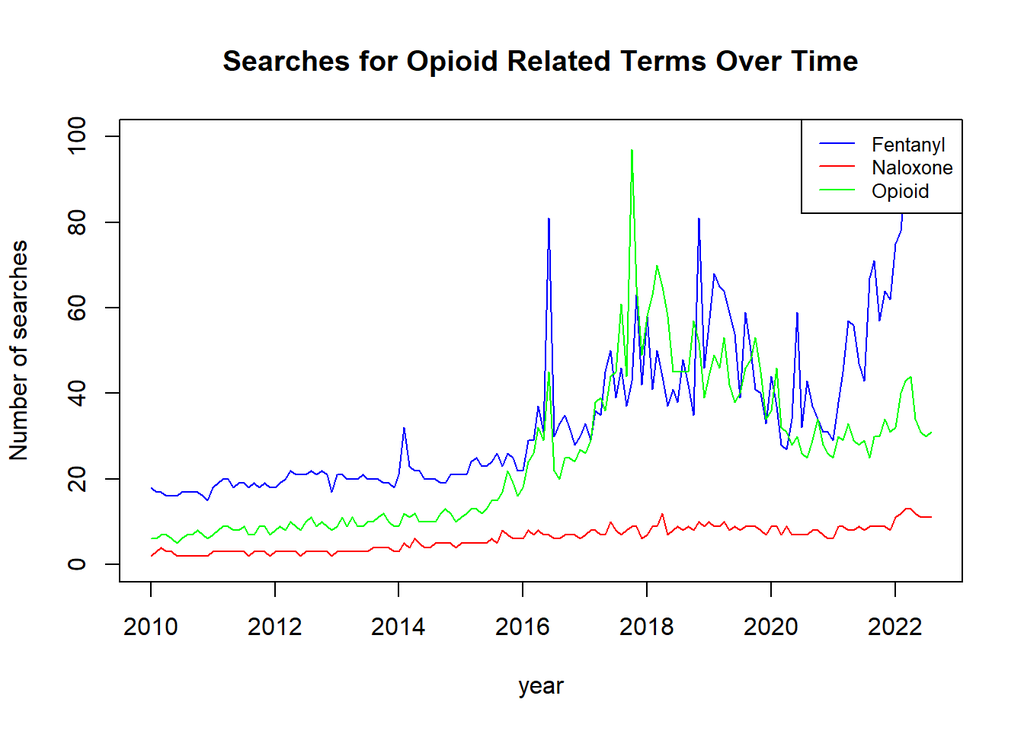

```r
#eksempelet er fra https://rpubs.com/keshob/742936
library(gtrendsR)
library(reshape2)
googleData =gtrends(c("Naloxone", "opioid", "fentanyl"),geo=c("US"), gprop = "web",  time = "2010-01-01 2022-08-24"
)[[1]]
googleData =dcast(googleData, date~keyword+geo, value.var = "hits")

plot(googleData$date, googleData$fentanyl_US, type='l', col='blue', ylab = "Number of searches", xlab= "year",
     main = "Searches for Opioid Related Terms Over Time",ylim = c(0, 100))
lines(googleData$date, googleData$Naloxone_US, type='l', col='red')
lines(googleData$date, googleData$opioid_US, type='l', col='green')
legend("topright", legend =c("Fentanyl", "Naloxone", "Opioid"), col=c("blue", "red", "green"), lwd = 1, cex=0.8)
```

## 4.4 Forsikringsmarkedet som helhet: Privat forsikring og tvungen sosialforsikring

## 4.4.1 Eksistensen og effektiviteten til private forsikringsmarkeder

- Eksistensen og effektiviteten av privat forsikring hviler på tre sett med forhold:
  - etterspørselen etter forsikring må være større enn null, $V = \overline{y} - y^{*}$
  - ingen av de tekniske problemene forårsaker problemer på tilbudssiden, se problemene i 4.3
  - det må være mulig å levere forsikring til en pris den enkelte er villig til å betale
    $$V = \overline{y} - y^{*} \ge 0$$

    $$\phi = \pi - pL$$
    $$\phi = \alpha pL$$

    $$\overline{y} - y^{*} \ge \alpha pL$$
- Forsikring kan tilbys til en pris den enkelte er villig til å betale bare når hans eller hennes risikoaversjon (representert ved forskjellen mellom $\overline{y}$ og $y^{*}$) er tilstrekkelig til å dekke forsikringsgiverens påslag, $\alpha pL$.

## 4.4.2 Tvungen sosialforsikring

- Skiller seg fra aktuarisk forsikring på to måter:
- Tvungen **sosialforsikring** (trygd) som respons på problemet med **ugunstig utvalg**
  - **Obligatorisk** medlemskap (pooling er mulig)
- Kontraktene er uklare (de kan endres)
  - betalinger kan gjenspeile uforutsette hendelser
  - gir beskyttelse mot usikkerhet samt risiko
- Forsikringspremie er ikke beregnet ut fra den enkeltes risikoklasse, finansieringen skjer via skattesystemet
- Lavrisikogruppen vil subsidiere høyrisikogruppen ved pooling
  - Noen vil opplagt tjene på offentlig forsikring
  - Er det en omfordeling vi foretrekker?
- Ineffektivt i Pareto-forstand, men bedre enn ingenting, dvs. det beste vi kan få til
- «First-best» er ikke mulig ved asymmetrisk informasjon

## Konklusjoner

- Offentlig, tvungen forsikring løser problemet med uheldig utvalg:
  - alle må forsikre seg, også de med lav risiko
  - sparer også administrasjonsutgifter, spesielt til å samle inn opplysninger om forsikringstakerne
  - I denne forstand: offentlig, tvungen sosialforsikring er mer effektiv enn private ordninger
- Problemet atferdsrisiko løses ikke ved tvungen forsikring
  - Bekymring ved sykelønn, dagpenger under arbeidsløshet, uførhetspensjon,osv.